# Lab Week 03 - 01-24-2022

Pouria

1/21/2022

# Lab 1

In this first exercise, we will simulate different datasets

$$y = 2 + 3 *X + \epsilon,$$

with $X$ randomly generated via a uniform distribution from 0 to 10, and $\epsilon$ generated via a normal (Gaussian) distribution of 0 mean and variance 1 (which we note, $\epsilon \sim N(\mu, \sigma^2)$, where $\mu=0$ and $\sigma=1$)

# Lab 1(a)

Generate 10 “experiments” with 5 observations each. Compute the slopes and the intercepts using the formula of Equation 3.4, check that the values are the same as given by the lm function in R , and plot the 10 different lines. Also plot in bold the “true” line.

# Coefficient Estimation Function

### Better define your computational algorithms as functions

Let’s define the equations of the least squares approach to obtain values of $\hat{\beta_0}$ and $\hat{\beta_1}$ that minimize the **residual sum of squares** (RSS).

```r
Eq3.4 <- function(X, y){

  # Equations 3.4 to estimate beta0 and beta1
  beta1 = sum((X-mean(X))*(y-mean(y))) / sum((X-mean(X))^2)
  beta0 = mean(y) - beta1*mean(X)

  return(list(beta0, beta1))
}
```

# The Loop of Experiments Function

### Define the experiments in a loop as a function

```r
Experiment <- function(N.Obs, N.Exp, X.min, X.max, epsilon.mu, epsilon.sd){

  beta0 <- beta1 <- 0
  beta0_lm <- beta1_lm <- 0
  SE_beta1 <- 0

  for (i in 1:N.Exp){
    X = runif(N.Obs, min = X.min, max = X.max)
    epsilon = rnorm(N.Obs, mean = epsilon.mu, sd = epsilon.sd)
    y = 2 + 3*X + epsilon

    coeff <- Eq3.4(X, y)
    beta0[i] <- coeff[[1]]
    beta1[i] <- coeff[[2]]

    SE_beta1[i] <- sqrt(epsilon.sd^2 / sum((X-mean(X))^2) )

    fit.lm <- lm(y~X)
    beta0_lm[i] <- fit.lm$coefficients[1]
    beta1_lm[i] <- fit.lm$coefficients[2]
  }

  return(data.frame(beta0, beta1, SE_beta1, beta0_lm, beta1_lm))
}
```

# Visualization function

### Plot the 10 different lines and the “true” line

```r
Visualize <- function(Coeff.df){
  ggplot() +
    geom_abline(data = Coeff.df, aes(slope=beta1 , intercept=beta0), col=4) +
    geom_abline(aes(slope = 3, intercept = 2), size=1.5, col=2) +
    scale_x_continuous(name="X", limits=c(-2,2)) +
    scale_y_continuous(name="y", limits=c(-10,10))
}
```

# Solution 1(a)

### Always define your parameters first.

Let’s assign values to the parameters in the problem:

```r
N.Exp = 10
N.Obs = 5
X.min = 0
X.max = 10
epsilon.mu = 0
epsilon.sd  = 1
```

# Solution 1(a)

### Coefficients for 5 observations from 10 experiments

```r
Coeff.df <- Experiment(N.Obs, N.Exp, X.min, X.max, epsilon.mu, epsilon.sd)
Coeff.df
```

```
##        beta0    beta1  SE_beta1  beta0_lm beta1_lm
## 1  1.2084739 3.349133 0.2190469 1.2084739 3.349133
## 2  2.0557013 2.945461 0.1879196 2.0557013 2.945461
## 3  2.1029224 2.977593 0.1842021 2.1029224 2.977593
## 4  2.7366520 2.869167 0.2000967 2.7366520 2.869167
## 5  0.2570336 3.315650 0.3559387 0.2570336 3.315650
## 6  0.4074639 3.333370 0.1699709 0.4074639 3.333370
## 7  0.6649933 3.018756 0.1438782 0.6649933 3.018756
## 8  1.6147229 2.887766 0.1763241 1.6147229 2.887766
## 9  1.5442662 3.101481 0.2427571 1.5442662 3.101481
## 10 2.4168356 2.901277 0.1387053 2.4168356 2.901277
```

# Solution 1(a)

### Visualize for 5 observations from 10 experiments

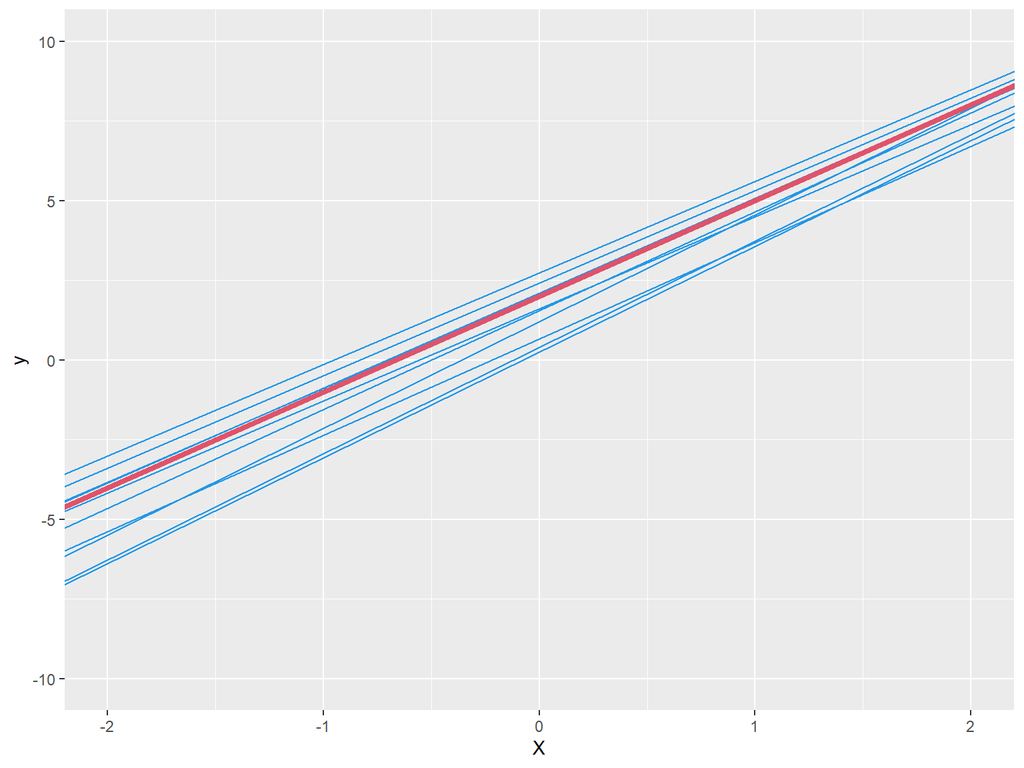

```r
Visualize(Coeff.df)
```

# Lab 1(b)

Now repeat 10 experiments, but with 20 observations each.

# Solution 1(b)

Let’s assign values to the parameters for problem 1(b):

```r
N.Exp = 10
N.Obs = 20
X.min = 0
X.max = 10
epsilon.mu = 0
epsilon.sd  = 1
```

# Solution 1(b)

### Coefficients for 20 observations from 10 experiments

```r
Coeff.df <- Experiment(N.Obs, N.Exp, X.min, X.max, epsilon.mu, epsilon.sd)
Coeff.df
```

```
##       beta0    beta1   SE_beta1 beta0_lm beta1_lm
## 1  2.714662 2.892329 0.07937062 2.714662 2.892329
## 2  1.381409 3.121712 0.10098988 1.381409 3.121712
## 3  2.131948 3.007595 0.08114276 2.131948 3.007595
## 4  2.293226 2.982017 0.10006583 2.293226 2.982017
## 5  2.206503 2.980137 0.07234074 2.206503 2.980137
## 6  2.926771 2.845880 0.08017438 2.926771 2.845880
## 7  1.443514 3.135374 0.07366505 1.443514 3.135374
## 8  1.393701 3.039130 0.10639183 1.393701 3.039130
## 9  2.253189 2.930945 0.08700245 2.253189 2.930945
## 10 2.332102 2.946141 0.07441854 2.332102 2.946141
```

# Solution 1(b)

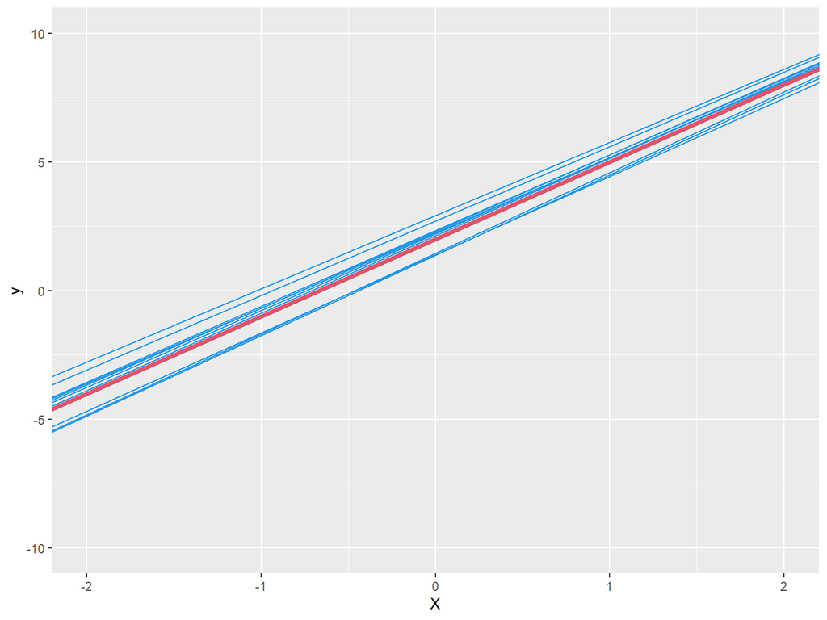

```r
Visualize(Coeff.df)
```

# Lab 1(c)

For each 5 and 20 observations, use the formula of equations 3.8 to compute the SE for the slope. Why is the SE smaller for 20 observations?

Equation 3.8:

$$SE(\hat{\beta_0})^2 = \sigma^2[\frac{1}{n} + \frac{\bar{x}^2}{\sum_{i=1}^{n}(x_i-\bar{x})^2 }],$$
$$SE(\hat{\beta_1})^2 = \frac{\sigma^2}{\sum_{i=1}^{n}(x_i-\bar{x})^2 }$$

##Solution 1(c)

[figure not shown]

# Lab 2

Now we will try to estimate the coefficients via systematic simulations

*(a)* Using one data set with 20 observations, and using 2 for loops as we discuss in class, generate a figure like figure 3.2 in the book.

# Define the function for calculating RSS

```r
RSS_func <- function(b0, b1, X, y){
  y_hat = b0 + b1*X
  RSS = sum( ( y-y_hat )^2 )

  return(RSS)
}
```

```r
i <- 0

N.Obs = 20
X = runif(N.Obs, min = X.min, max = X.max)
epsilon = rnorm(N.Obs, mean = epsilon.mu, sd = epsilon.sd)
y = 2 + 3*X + epsilon

beta1 <- beta0 <- 0
RSS <- 0

for (bet0 in seq(-100,100,.4)){
  for (bet1 in seq(-50,50,.4)){
    i <- i+1
    beta0[i] <- bet0
    beta1[i] <- bet1
    RSS[i]   <- RSS_func(bet0, bet1, X, y)
  }
}

beta0.opt <- beta0[RSS==min(RSS)]
beta1.opt <- beta1[RSS==min(RSS)]
```

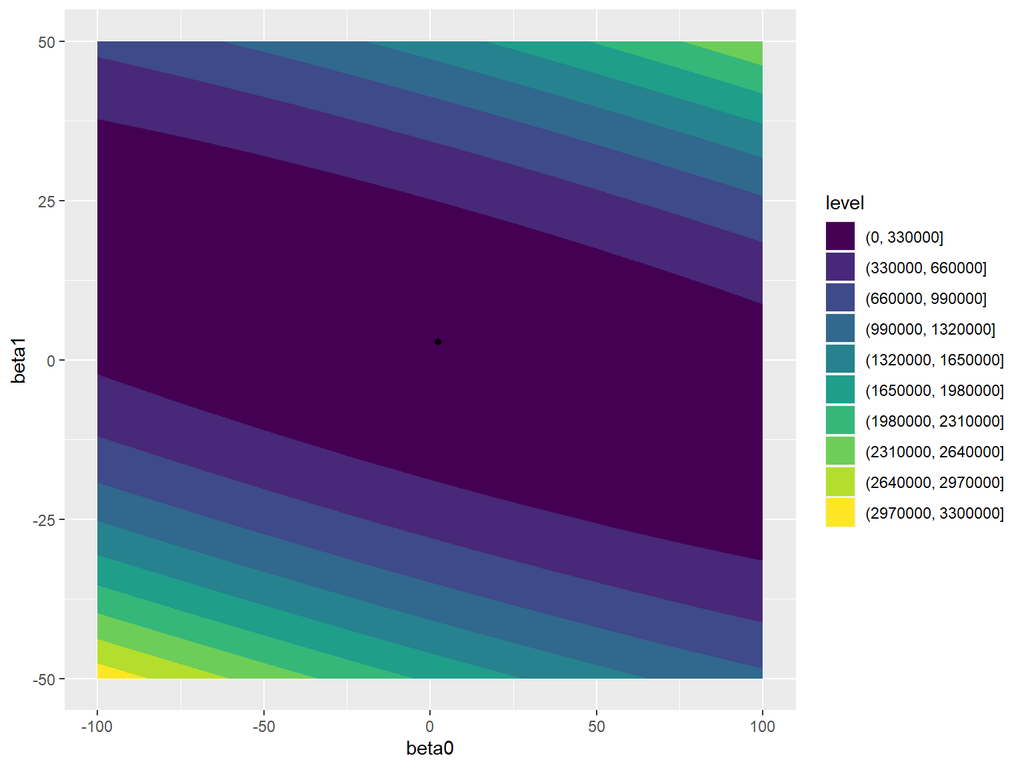

```r
df.RSS = data.frame(beta0, beta1, RSS)
var.opt = data.frame(beta0.opt, beta1.opt)

ggplot(df.RSS, aes(beta0, beta1, z=RSS)) +
  geom_contour_filled(bins=10) +
  geom_point(aes(x = beta0.opt, y = beta1.opt), shape=19)
```

# Lab 3

Now we will try to estimate the parameters via a method called “gradient descent”. Given a random starting point, we will “descend” along the steepest gradient in parameter space until we converge to the minimum.

$$\hat{y}=X\theta$$
$$L=\frac{1}{2m}\sum_{i=1}^{m}(y_i-\hat{y}_i)^2$$
$$L=\frac{1}{2m}(\mathbf{y}-X\theta)^T(\mathbf{y}-X\theta)$$